# NDNS multilevel LCA CW2CB2 or CW2CB3

Chaochen Wang

19 July 2018

# 1 Steps of conducting a multilevel LCA

- Firstly, we ignored the multilevel structure of the data and estimated a series of traditional LC models to determine the number of classes at the observational-level;
- Next, a series of MLCA models were fitted to account for the multi-level structrure of the data. In these models, the number of observational-level classes was based on the best fitting LCA model from the first step, and the LCA model at the individual-level was estimated to identify the number of individual-level latent classes;
- Thirdly, when number of individual-level latent classes is defined based on the previous stage, observational-level classes was modified (one class lower and one class higher than in the second step), to see the effect of changing level 1 classes and confirm the best fitting model.

## 1.1 How to decide the number of classes in level 1 and/or level 2 data

The number of classes in either level 1 were determined by

1. the evaluation of model fit indices, including the Akaike information criterion (AIC), Bayesian information criterion (BIC), adjusted Bayesian information criterion (aBIC) where smaller values indicate better, and entropy which is a statistic that summarizes latent class probabilities where values near 1 indicate better latent class separation;
2. the Lo-Mendell-Rubin Likelihood Ratio Test (LMR-LRT) and the Bootstrap Likelihood ratio test (BS-LRT) which compare $q$ vs. $q-1$ class models, where $q$ is the number of latent classes;
3. pattern interpretability.
4. In the step of performing multilevel LCA, where neither LMR-LRT nor BS-LRT were available, same rules of model fit indices and pattern interpretability were used to determine the optimal combination of latent classes in level 1 and level 2.

# 2 Level 1 classes selection

- In this analysis, within each hour of the day carbohydrates intake was defined as:
  - not eating;
  - eating and carbohydrates contributed less than 50% of energy;
  - eating and carbohydrates contributed higher or equal to 50% of energy.

Level 1 class selection. (All data, n = 6155, 24483 data points)

| N of classes | N of free parameters | log-likelihood | AIC | BIC | aBIC | Entropy | Lo-Mendel-Rubin LRT |
| --- | --- | --- | --- | --- | --- | --- | --- |
| 1 | 48 | -372017.3 | 744130.6 | 744519.7 | 744367.1 | – | — |
| 2 | 97 | -368913.7 | 738021.4 | 738807.7 | 738499.4 | 0.777 | < 0.0001 |
| 3 | 146 | -366665.0 | 733621.9 | 734805.4 | 734341.4 | 0.666 | < 0.0001 |
| 4 | 195 | -365528.6 | 731447.1 | 733027.7 | 732408.0 | 0.658 | 0.8478 |
| 5 | 244 | -364901.2 | 730290.3 | 732268.1 | 731492.7 | 0.648 | 0.7602 |
| 6 | 293 | -363641.8 | 727869.5 | 730244.5 | 729313.4 | 0.701 | 0.7632 |
| 7 | 342 | -362789.9 | 726263.7 | 729035.9 | 727949.0 | 0.729 | 0.7702 |
| 8 | 391 | -362047.9 | 724877.9 | 728047.2 | 726804.6 | 0.737 | 0.8261 |

Note:  
Abbreviation: N, number; AIC, Akaike information criterion; BIC, Bayesian information criterion; aBIC, adjusted BIC; Entropy, a pseudo-r-squared index; Lo-Mendel-Rubin LRT, likelihood ratio test comparing q classes models with q-1 classes models.

## 2.1 Fit information for each model (combination of level 1 and level 2 classes)

Models Specification

[output not shown]

Note:  
Abbreviation: No, number; BIC, Bayesian information criterion; Entropy, a pseudo-r-squared index; Lo-Mendel-Rubin LRT, likelihood ratio test comparing q classes models with q-1 classes models.

## 2.2 Visualisation of level 1 latent classes (CW = 2)

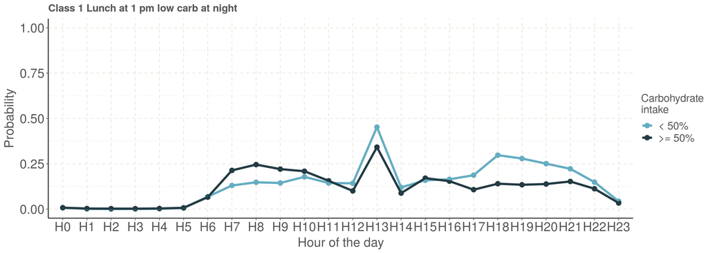

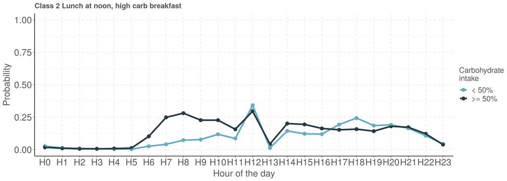

## 2.3 Visualisation of level 2 latent classes (CB = 2)

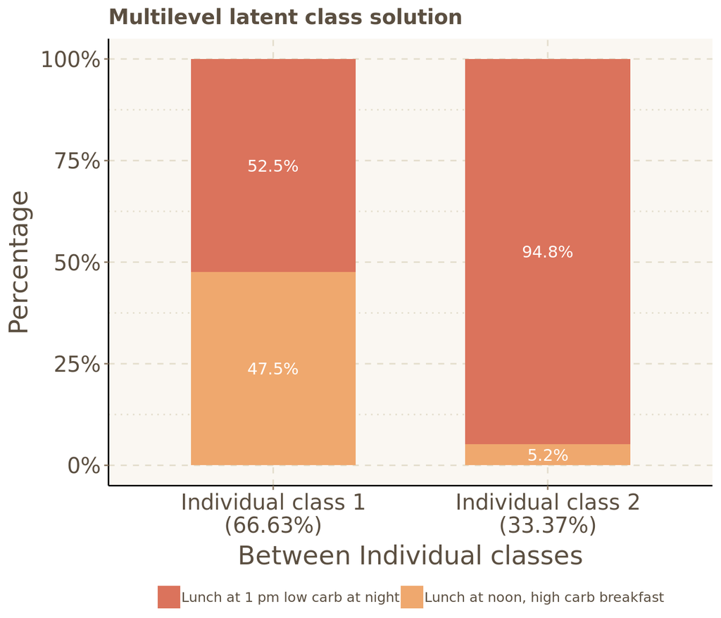

## 2.4 Visualisation of level 2 latent classes (CB = 3)

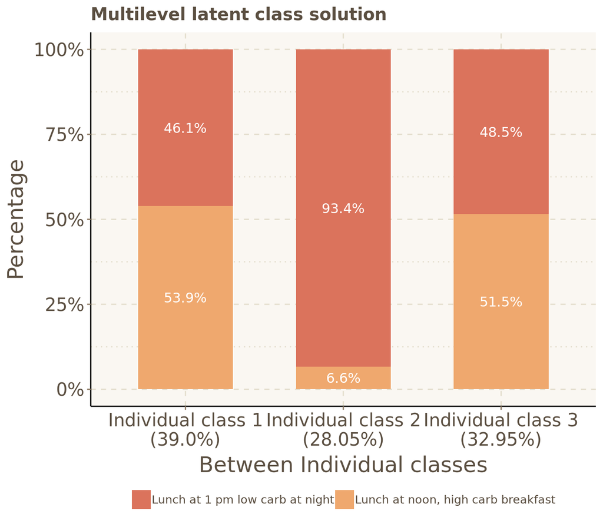